# Transciptomic analysis using `limma`

Juan R Gonzalez

Bioinformatics Research Group in Epidemiology, Barcelona Institute for Global Health, Spain

juanr.gonzalez@isglobal.org

January, 2020

#### Abstract

Brief introduction to microarray data analysis using `limma`.

# 1 Gettig started

This document can be reproduced by using the R code and the data (for illustrating purposes and for the excersises) that are available here: https://github.com/isglobal-brge/post_omic

# 2 Introduction

Transcriptomic data analysis can be performed using data obtained from two infrastructures: microarrays and RNA-seq. This lectures describe the main steps to perform differential expression analysis (DEA) using microarray data. This is a brief introduction that covers the main aspects of DEA and outliens other methodologies that should be consider in this type of analyses but would require more than 2 hours.

## 2.1 Microarray workflow

A basic protocol for a DNA microarray is as follows:

- **Isolate and purify mRNA from samples of interest**. Since we are interested in comparing gene expression, one sample usually serves as control, and another sample would be the experiment (healthy vs. disease, etc)
- **Reverse transcribe and label the mRNA**. In order to detect the transcripts by hybridization, they need to be labeled, and because starting material maybe limited, an amplification step is also used. Labeling usually involves performing a reverse transcription (RT) reaction to produce a complementary DNA strand (cDNA) and incorporating a florescent dye that has been linked to a DNA nucleotide, producing a fluorescent cDNA strand. Disease and healthy samples can be labeled with different dyes and cohybridized onto the same microarray in the following step. Some protocols do not label the cDNA but use a second step of amplification, where the cDNA from RT step serves as a template to produce a labeled cRNA strand.
- **Hybridize the labeled target to the microarray**. This step involves placing labeled cDNAs onto a DNA microarray where it will hybridize to their synthetic complementary DNA probes attached on the microarray. A series of washes are used to remove non-bound sequences.
- **Scan the microarray and quantitate the signal**. The fluorescent tags on bound cDNA are excited by a laser and the fluorescently labeled target sequences that bind to a probe generate a signal. The total strength of the signal depends upon the amount of target sample binding to the probes present on that spot. Thus, the amount of target sequence bound to each probe correlates to the expression level of various genes expressed in the sample. The signals are detected, quantified, and used to create a digital image of the array.

If we are trying to calculate relative expression between two samples, each labeled with a different dye (See next figure, red for experiment, green for control), the resulting image is analyzed by calculating the ratio of the two dyes. If a gene is over-expressed in the experimental sample, then more of that sample cDNA than control cDNA will hybridize to the spot representing that expressed gene. In turn, the spot will fluoresce red with greater intensity than it will fluoresce green. The red-to-green fluorescence ratio thus indicates which gene is up or downregulated in the appropriate sample.

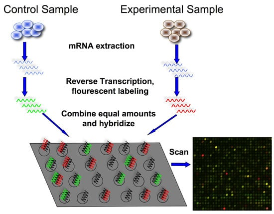

Microarray Experiment

*limma* is a widely used BioC package for analyzing microarray data. LIMMA stands for “linear models for microarray data”. Perhaps unsurprisingly, `limma` contains functionality for fitting a broad class of statistical models called “linear models”. Examples of such models include linear regression and analysis of variance. While most of the functionality of limma has been developed for microarray data, the model fitting routines of limma are useful for many types of data, and is not limited to microarrays. For example, DNA methylation data is also used to be analyzed using this package.

## 2.2 `limma` manual

- The limma User’s Guide from the [limma webpage](http://bioconductor.org/packages/limma). This is an outstanding piece of documentation which contains serveal examples of DEA for different designs that can be used to answer different scientific questions. It is without any doubt “the best resource on differential expression analysis available”.

## 2.3 Model design

The objective of an DEA is frequently to discover which features (genes) are different between groups or stated differently: to discover which genes are differentially expressed between cases and controls. Of course, more complicated designs are also used; sometimes more than two groups are considered and sometimes there are additional important covariates such as age or sex that should be taken into accout (adjusted models).

Broadly speaking, how samples are distributed between groups determines the **design** of the study. In addition to the design, there is one or more question(s) of interest(s) such as the difference between two groups. Such questions are usually formalized as **contrasts**; an example of a contrast is indeed the difference between two groups.

This can be formalized as

$$Y = \beta_0 + \beta_1 X_1 + \epsilon$$

In this equation of a linear model, Y is the response variable. It must be a continuous variable. In the context of DEA, it is a relative measure of mRNA expression level for one gene. $X_1$ is an explanatory variable, which can be continuous or discrete, for example, control group versus treatment, or mutant versus wild type. $\beta_1$ quantifies the effect of the explanatory variable on the response variable. Furthermore, we can add additional explanatory variables to the equation for more complicated experimental designs. Lastly, models the random noise in the measurements.

In R, you specify a linear model with the function `lm`. This uses R’s formula syntax. On the left is the object that contains the response variable, and to the right of the tilde are the objects that contain the explanatory variables.

```r
lm(y ~ x1)
```

A second explanatory variable can be added with a plus sign.

$$Y = \beta_0 + \beta_1 X_1 + \beta_2 X_2 + \epsilon$$

```r
lm(y ~ x1 + x2)
```

The design matrix is then, how samples are distributed accross x1 and x2. Let us illustrate this in a simple simulated case when DEA aims to find genes that are differentially expressed between cases and control (variable x1)

```r
set.seed(1234) # to guarantee reproducibility
x1 <- as.factor(sample(c("case", "control"), 10, replace=TRUE))
x1
```

```
 [1] control control control control case    control case    case    case    control
Levels: case control
```

```r
model.matrix( ~ x1)
```

```
   (Intercept) x1control
1            1         1
2            1         1
3            1         1
4            1         1
5            1         0
6            1         1
7            1         0
8            1         0
9            1         0
10           1         1
attr(,"assign")
[1] 0 1
attr(,"contrasts")
attr(,"contrasts")$x1
[1] "contr.treatment"
```

The data structure represented by an `ExpressionSet` or a `SummarizedExperiment` contains features in the rows of the experimental data and variables in columns.

A number of different packages allows us to fit common types of models to this data structure

- *limma* fits a so-called linear model; examples of linear models are (1) linear regression, (2) multiple linear regression and (3) analysis of variance.
- *edgeR*, *DESeq* and *DESeq2* fits generalized linear models, specifically models based on the negative binomial distribution that will be illustrated in a later session.

Simplifyng, *limma* is useful for continuous data such as microarray data and *edgeR* / *DESeq* / *DESeq2* are useful for count data such as high-throughput sequencing (RNA-seq). Though will see that count data can also be transformed into continuous data and, hence, *limma* can also be used in that case.

# 3 Two group comparison

Let us illustrate how to perform DEA using `vdx` dataset which is available at Bioconductor through the package *breastCancerVDX*. This package can be installed along with `limma` using:

```r
BiocManager::install(c("limma", "breastCancerVDX"))
```

After that, the packages can be loaded into R by:

```r
library(limma)
library(breastCancerVDX)
```

The `vdx` dataset from the *breastCancerVDX* package is an `ExpressionSet` of women diagnosed with breast cancer. It contains information about 22,000 genes and several variables including estrogen receptor (ER) status.

```r
data(vdx)
vdx
```

```
ExpressionSet (storageMode: lockedEnvironment)
assayData: 22283 features, 344 samples
  element names: exprs
protocolData: none
phenoData
  sampleNames: VDX_3 VDX_5 ... VDX_2038 (344 total)
  varLabels: samplename dataset ... e.os (21 total)
  varMetadata: labelDescription
featureData
  featureNames: 1007_s_at 1053_at ... AFFX-TrpnX-M_at (22283 total)
  fvarLabels: probe Gene.title ... GO.Component.1 (22 total)
  fvarMetadata: labelDescription
experimentData: use 'experimentData(object)'
  pubMedIds: 17420468
Annotation: hgu133a
```

```r
table(vdx$er)
```

```
  0   1
135 209
```

The code `0` means negative and `1` positive estrogen receptor. Now we do a standard limma model fit

```r
design <- model.matrix(~ vdx$er)
fit <- lmFit(vdx, design)
fit <- eBayes(fit)
topTable(fit)
```

```
                  probe                                                     Gene.title Gene.symbol
205225_at     205225_at                                            estrogen receptor 1        ESR1
209603_at     209603_at                                         GATA binding protein 3       GATA3
209604_s_at 209604_s_at                                         GATA binding protein 3       GATA3
212956_at     212956_at                TBC1 domain family, member 9 (with GRAM domain)      TBC1D9
202088_at     202088_at          solute carrier family 39 (zinc transporter), member 6     SLC39A6
212496_s_at 212496_s_at                             lysine (K)-specific demethylase 4B       KDM4B
215867_x_at 215867_x_at                                         carbonic anhydrase XII        CA12
209602_s_at 209602_s_at                                         GATA binding protein 3       GATA3
212195_at     212195_at interleukin 6 signal transducer (gp130, oncostatin M receptor)       IL6ST
218195_at     218195_at                            chromosome 6 open reading frame 211    C6orf211
            Gene.ID EntrezGene.ID UniGene.title UniGene.symbol UniGene.ID
205225_at      2099          2099          <NA>           <NA>       <NA>
209603_at      2625          2625          <NA>           <NA>       <NA>
209604_s_at    2625          2625          <NA>           <NA>       <NA>
212956_at     23158         23158          <NA>           <NA>       <NA>
202088_at     25800         25800          <NA>           <NA>       <NA>
212496_s_at   23030         23030          <NA>           <NA>       <NA>
215867_x_at     771           771          <NA>           <NA>       <NA>
209602_s_at    2625          2625          <NA>           <NA>       <NA>
212195_at      3572          3572          <NA>           <NA>       <NA>
218195_at     79624         79624          <NA>           <NA>       <NA>
                                                                                                                                                                  Nucleotide.Title
205225_at                                                                                                      Homo sapiens estrogen receptor 1 (ESR1), transcript variant 1, mRNA
209603_at   wh43d10.x1 NCI_CGAP_Kid11 Homo sapiens cDNA clone IMAGE:2383507 3- similar to gb:X58072_rna1 TRANS-ACTING T-CELL SPECIFIC TRANSCRIPTION FACTOR (HUMAN);, mRNA sequence
209604_s_at                                                                            Homo sapiens GATA binding protein 3, mRNA (cDNA clone MGC:2346 IMAGE:3504200), complete cds
212956_at                                                                                          qp61g12.x1 NCI_CGAP_Co8 Homo sapiens cDNA clone IMAGE:1927558 3-, mRNA sequence
202088_at                                                                                         ts65a01.x1 NCI_CGAP_Kid8 Homo sapiens cDNA clone IMAGE:2233416 3-, mRNA sequence
212496_s_at                                                                                         601112063F1 NIH_MGC_16 Homo sapiens cDNA clone IMAGE:3352887 5-, mRNA sequence
215867_x_at                                                                                                         Homo sapiens mRNA; cDNA DKFZp564D066 (from clone DKFZp564D066)
209602_s_at wh43d10.x1 NCI_CGAP_Kid11 Homo sapiens cDNA clone IMAGE:2383507 3- similar to gb:X58072_rna1 TRANS-ACTING T-CELL SPECIFIC TRANSCRIPTION FACTOR (HUMAN);, mRNA sequence
212195_at                                                                                                           Homo sapiens mRNA; cDNA DKFZp564F053 (from clone DKFZp564F053)
218195_at                                                                                                        Homo sapiens chromosome 6 open reading frame 211 (C6orf211), mRNA
                   GI GenBank.Accession Platform_CLONEID Platform_ORF Platform_SPOTID
205225_at   170295798         NM_000125               NA           NA            <NA>
209603_at     5361632          AI796169               NA           NA            <NA>
209604_s_at  33871929          BC003070               NA           NA            <NA>
212956_at     4085300          AI348094               NA           NA            <NA>
202088_at     4686779          AI635449               NA           NA            <NA>
212496_s_at   9127367          BE256900               NA           NA            <NA>
```

[output cut: 77 more lines]

```
215867_x_at                                                                                            GO:0016021///GO:0016020
209602_s_at                                                                                                         GO:0005634
212195_at                GO:0070110///GO:0009897///GO:0005576///GO:0005615///GO:0016021///GO:0005896///GO:0005900///GO:0005886
218195_at                                                                                                                 <NA>
               logFC   AveExpr        t      P.Value    adj.P.Val         B
205225_at   3.762901 11.377735 22.68392 2.001001e-70 4.458832e-66 149.19866
209603_at   3.052348  9.941990 18.98154 1.486522e-55 1.656209e-51 115.46414
209604_s_at 2.431309 13.185334 17.59968 5.839050e-50 4.337052e-46 102.75707
212956_at   2.157435 11.702942 17.48711 1.665700e-49 9.279201e-46 101.72268
202088_at   1.719680 13.119496 17.30104 9.412084e-49 4.194589e-45 100.01376
212496_s_at 1.459843 10.703942 16.85070 6.188671e-47 2.298369e-43  95.88265
215867_x_at 2.246120 11.450485 16.79123 1.074845e-46 3.421537e-43  95.33780
209602_s_at 2.921505  9.547850 16.43202 3.004184e-45 8.367780e-42  92.05058
212195_at   1.381778 11.737839 16.31864 8.581176e-45 2.124604e-41  91.01458
218195_at   1.738740  9.479901 16.27378 1.299472e-44 2.895613e-41  90.60496
```

This is the common limma workflow. First, the comparison of interest (and the design of the experiment) is defined through a so-called “design matrix”. This matrix basically encompasses everything we know about the design; in this case there are two groups (we have more to say on the design below). Next, the model is fitted. This is followed by borrowing strength across genes using a so-called empirical Bayes procedure. Because this design only has two groups there is only one possible comparison to make: which genes differs between the two groups. This question is examined by the `topTable()` function which lists the top differentially expressed genes. In a more complicated design, the `topTable()` function would need to be told which comparison of interest to summarize.

An important part of the output is `logFC` which is the log fold-change. To interpret the sign of this quantity you need to know if this is `1-0` (e.g. ER+ vs ER-) (in which case positive values are up-regulated in ER+) or the reverse. In this case this is determined by the reference level which is the first level of the factor.

```r
head(as.factor(vdx$er))
```

```
[1] 0 1 0 0 0 1
Levels: 0 1
```

we see the reference level is `0` so positive values means it is down-regulated in ER-. You can change the reference level of a factor using the `relevel()` function. You can also confirm this by computing the `logFC` by hand, which is useful to know. Let’s compute the fold-change of the top differentially expressed gene:

```r
topTable(fit, n = 1)
```

```
              probe          Gene.title Gene.symbol Gene.ID EntrezGene.ID UniGene.title
205225_at 205225_at estrogen receptor 1        ESR1    2099          2099          <NA>
          UniGene.symbol UniGene.ID
205225_at           <NA>       <NA>
                                                             Nucleotide.Title        GI
205225_at Homo sapiens estrogen receptor 1 (ESR1), transcript variant 1, mRNA 170295798
          GenBank.Accession Platform_CLONEID Platform_ORF Platform_SPOTID Chromosome.location
205225_at         NM_000125               NA           NA            <NA>              6q25.1
                                      Chromosome.annotation
205225_at Chromosome 6, NC_000006.11 (152011631..152424409)
                                                                                                                                                                                                                                                                                                            …
205225_at estrogen receptor activity///estrogen response element binding///hormone binding///metal ion binding///nitric-oxide synthase regulator activity///protein binding///protein complex binding///sequence-specific DNA binding///steroid binding///steroid hormone receptor activity///transcription …
                                                                                                                                                                                                                                                                                                            …
205225_at androgen metabolic process///antral ovarian follicle growth///epithelial cell development///epithelial cell proliferation involved in mammary gland duct elongation///estrogen receptor signaling pathway///male gonad development///mammary gland alveolus development///mammary gland branching …
                                                                                                                                           GO.Component
205225_at T-tubule///chromatin remodeling complex///cytoplasm///membrane///neuron projection///nucleus///perikaryon///plasma membrane///terminal button
                                                                                                                                                                   GO.Function.1
205225_at GO:0030284///GO:0034056///GO:0042562///GO:0046872///GO:0030235///GO:0005515///GO:0032403///GO:0043565///GO:0005496///GO:0003707///GO:0003700///GO:0008134///GO:0008270
                                                                                                                                                                                                                                                                                         GO.Process.1
205225_at GO:0008209///GO:0001547///GO:0002064///GO:0060750///GO:0030520///GO:0008584///GO:0060749///GO:0060745///GO:0043526///GO:0002076///GO:0048146///GO:0048386///GO:0045885///GO:0060527///GO:0060523///GO:0060687///GO:0006355///GO:0032355///GO:0007165///GO:0006351///GO:0060065///GO:0060068
                                                                                                              GO.Component.1
205225_at GO:0030315///GO:0016585///GO:0005737///GO:0016020///GO:0043005///GO:0005634///GO:0043204///GO:0005886///GO:0043195
             logFC  AveExpr        t      P.Value    adj.P.Val        B
205225_at 3.762901 11.37774 22.68392 2.001001e-70 4.458832e-66 149.1987
```

```r
genename <- rownames(topTable(fit, n=1))
typeMean <- tapply(exprs(vdx)[genename,], vdx$er, mean)
typeMean
```

```
        0         1
 9.091554 12.854455
```

```r
typeMean["1"] - typeMean["0"]
```

```
       1
3.762901
```

confirming the statement. It is sometimes useful to check things by hand to make sure you have the right interpretation. Finally, note that limma doesn’t do anything different from a difference of means when it computes `logFC`; all the statistical improvements centers on computing better t-statistics and p-values.

The reader who has some experience with statistics will note that all we are doing is comparing two groups; this is the same setup as the classic t-statistic. What we are computing here is indeed a t-statistic, but one where the variance estimation (the denominator of the t-statistics) is *moderated* by borrowing strength across genes (this is what `eBayes()` does); this is called a moderated t-statistic.

The output from `topTable()` includes

- `logFC`: the log fold-change between cases and controls.
- `t`: the t-statistic used to assess differential expression.
- `P.Value`: the p-value for differential expression; this value is not adjusted for multiple testing.
- `adj.P.Val`: the p-value adjusted for multiple testing. Different adjustment methods are available, the default is Benjamini-Horchberg.

How to setup and interpret a design matrix for more complicated designs is beyond the scope of this introduction. The limma User’s Guide is extremely helpful here. Also, note that setting up a design matrix for an experiment is a standard task in statistics (and requires very little knowledge about genomics), so other sources of help is a local, friendly statistician or text books on basic statistics.

# 4 Important issues

- Data normalization *oligo* function `rma`
- Surrogate variable analysis *sva*
- Cell-type estimation `biocLite('CellMix', siteRepos = 'http://web.cbio.uct.ac.za/~renaud/CRAN', type='both')`

Inflation (produced by batch effects or uncontrolled variables) is normally tested by using QQ-plot

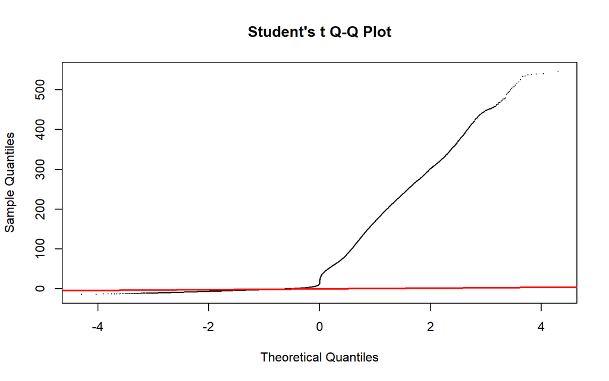

```r
qqt(fit$t, df=fit$df.prior+fit$df.residual,
    pch=16,cex=0.2)
abline(0,1, col="red", lwd=2)
```

Surrogate variable analysis (SVA) can be used to correct for uncontrolled variables. The [sva package](http://bioconductor.org/packages/release/bioc/vignettes/sva/inst/doc/sva.pdf) can be used to this end. This procedure is implemened in the [MEAL package](https://bioconductor.org/packages/release/bioc/html/MEAL.html) that requires less R code. Note that `fNames` argument allows to add annotation to the results by passing any of the existing variables in the feature data (`fData`) of the `ExpressionSet` object

```r
library(MEAL)

# shows available annotated variabels
names(fData(vdx))
```

```
 [1] "probe"                 "Gene.title"            "Gene.symbol"           "Gene.ID"
 [5] "EntrezGene.ID"         "UniGene.title"         "UniGene.symbol"        "UniGene.ID"
 [9] "Nucleotide.Title"      "GI"                    "GenBank.Accession"     "Platform_CLONEID"
[13] "Platform_ORF"          "Platform_SPOTID"       "Chromosome.location"   "Chromosome.annotation"
[17] "GO.Function"           "GO.Process"            "GO.Component"          "GO.Function.1"
[21] "GO.Process.1"          "GO.Component.1"
```

```r
# DEA
ans <- runPipeline(vdx, variable = "er")
ans
```

```
Object of class 'ResultSet'
 . created with: runPipeline
 . sva:  no
 . #results: 2 ( error: 0 )
 . featureData: 22283 probes x 22 variables
```

```r
# DEA + SVA
ans.sva <- runPipeline(vdx, variable = "er", sva=TRUE)
ans.sva
```

```
Object of class 'ResultSet'
 . created with: runPipeline
 . sva:  yes
 . #results: 2 ( error: 0 )
 . featureData: 22283 probes x 22 variables
```

```r
fit.meal <- getProbeResults(ans, coef=2,
                       fNames=c("probe", "Gene.symbol", "Chromosome.location"))
head(fit.meal)
```

```
               logFC     CI.L     CI.R  AveExpr        t      P.Value    adj.P.Val         B
205225_at   3.762901 3.436632 4.089169 11.37774 22.68392 2.001001e-70 4.458832e-66 149.19866
209603_at   3.052348 2.736067 3.368629  9.94199 18.98154 1.486522e-55 1.656209e-51 115.46414
209604_s_at 2.431309 2.159599 2.703020 13.18533 17.59968 5.839050e-50 4.337052e-46 102.75707
212956_at   2.157435 1.914779 2.400091 11.70294 17.48711 1.665700e-49 9.279201e-46 101.72268
202088_at   1.719680 1.524180 1.915180 13.11950 17.30104 9.412084e-49 4.194589e-45 100.01376
212496_s_at 1.459843 1.289447 1.630239 10.70394 16.85070 6.188671e-47 2.298369e-43  95.88265
                    SE       probe Gene.symbol Chromosome.location
205225_at   0.05434399   205225_at        ESR1              6q25.1
209603_at   0.08505077   209603_at       GATA3               10p15
209604_s_at 0.06235462 209604_s_at       GATA3               10p15
212956_at   0.04006799   212956_at      TBC1D9             4q31.21
202088_at   0.09917443   202088_at     SLC39A6             18q12.2
212496_s_at 0.05482533 212496_s_at       KDM4B             19p13.3
```

The QQ-plot is then produced by

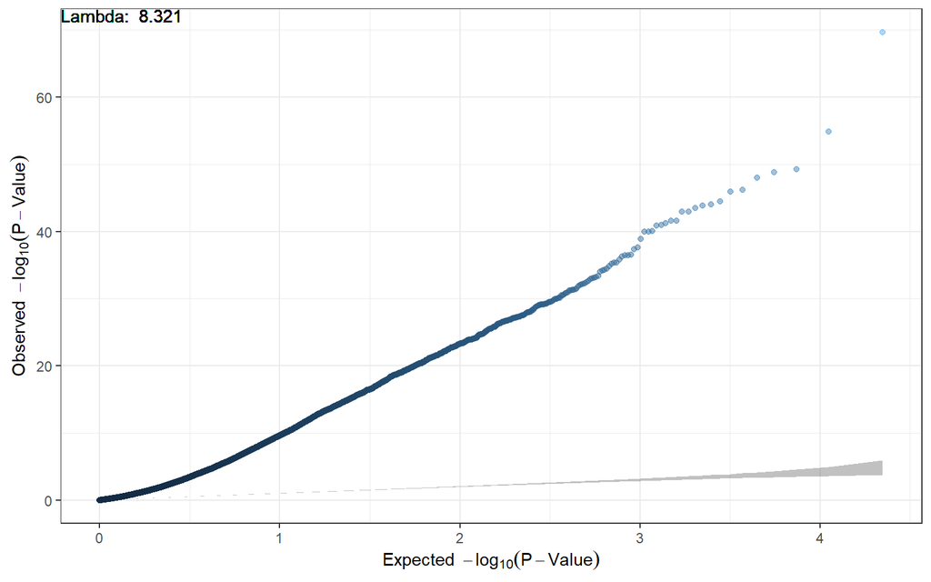

```r
plot(ans, type="QQ")
```

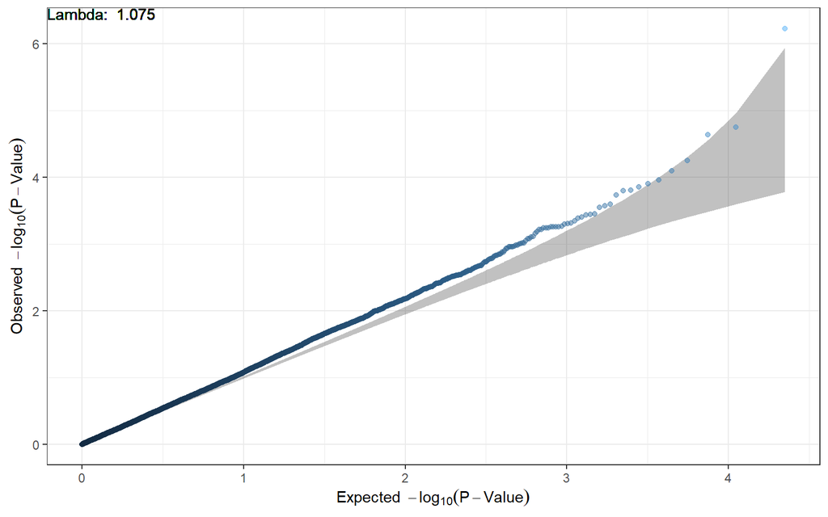

```r
plot(ans.sva, type="QQ")
```

There is still inflation, that may be due to cell-types differences, but this result can be considered acceptable.

# 5 Data visualization

Volcano plot can be use to visualize the genes that are differentially expressed at a given fold-change and p-value. The function `volcanoplot` from `limma` package can be used to this end.

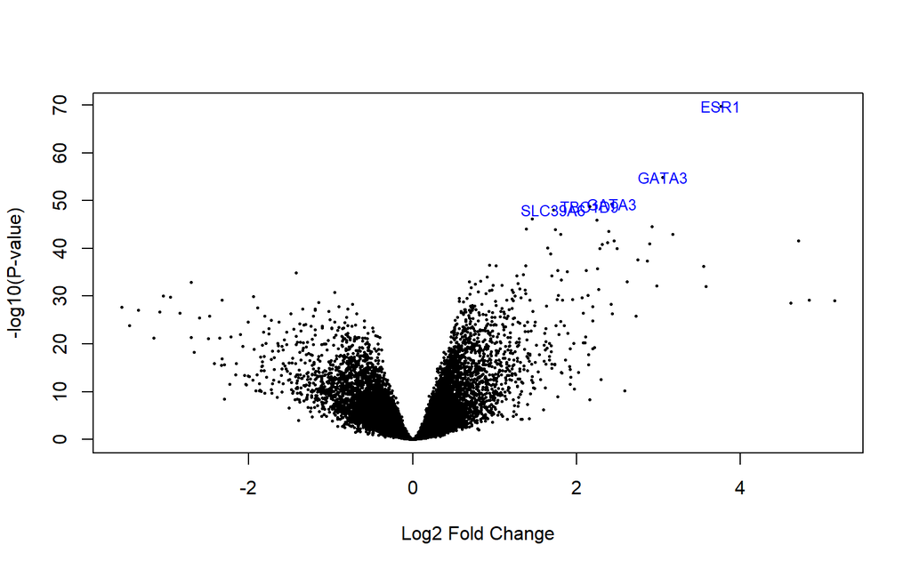

```r
volcanoplot(fit, coef=2, names = fit$genes$Gene.symbol,
            highlight = 5)
```

`MEAL` has an user-friedly function to facilitate this visualization

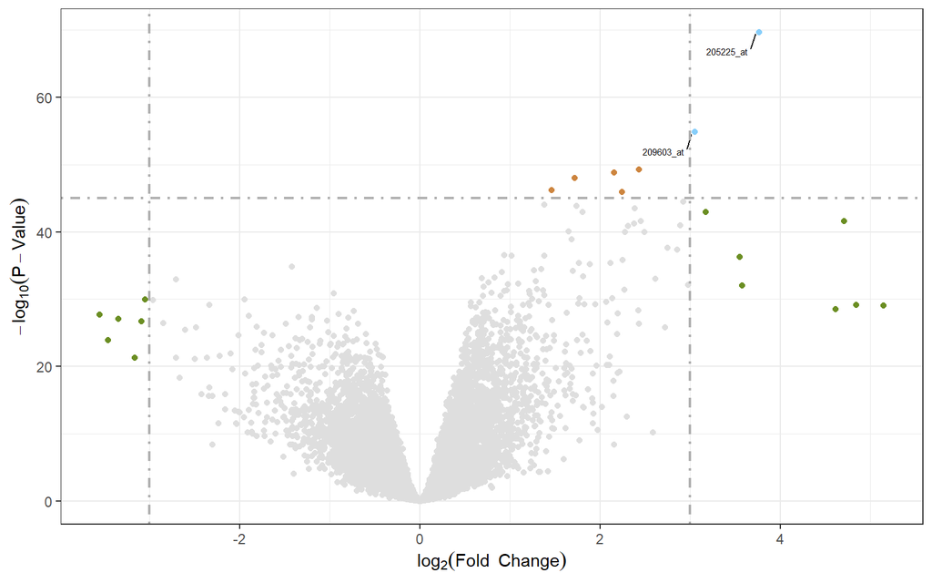

```r
plot(ans, type="volcano", tFC=3, tPV=45)
```

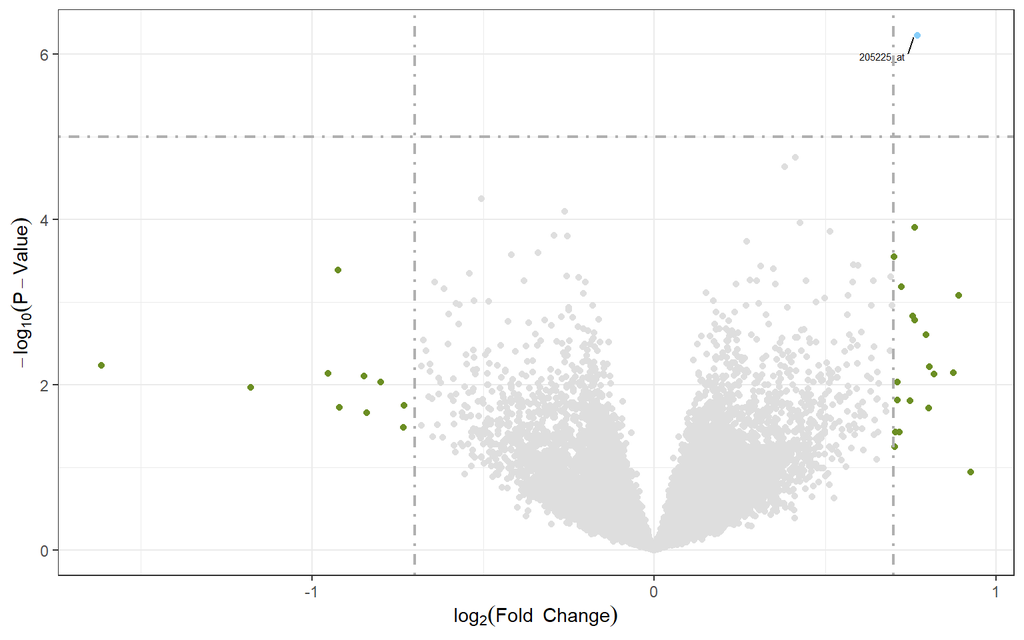

```r
plot(ans.sva, type="volcano", tFC=0.7, tPV=5)
```

Another state-of-the-art plot is MA-plot. It is used to check whether data are comparable among groups (i.e. normalization worked properly). This can be created using a function available in `limma`.

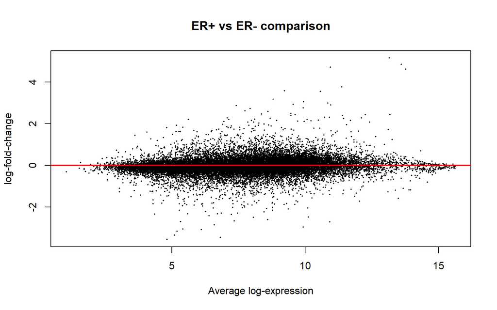

```r
plotMA(fit, coef=2, main="ER+ vs ER- comparison")
abline(h=0, col="red", lwd=2)
```

**EXERCISE**: *leukemiasEset* provides transcriptomic data for different types of leukemias. It can be loaded into R by `data(leukemiasEset)` after loading the package. The variable `LeukemiaType` encodes several types of leukemia as well as control sampels (`NoL`). Perform a complete differential expression analysis comparing `CML` versus `NoL`.

# 6 Acknowledgments

The description of the microarry experiment has been brougth from [bitesizebio](https://bitesizebio.com/7206/introduction-to-dna-microarrays/). Some parts of this material has been obtained from Kasper D. Hansen material of the course Bioconductor for Genomic Data Science